# Harmful & Economic impact on inclement weather events in US

Prashanth Jayaseelan

January 6, 2017

# Synopsis

This analysis is targeted to answer specific questions towards inclement weather events and their impacts. Goal is to find out which types of weather events are most harmful on the populations health in respect of general injuries and fatalities. Further the economic consequences are analyzed by exploring the financial damage done to both property and crops.

For this research, the NOAA strom database was used and is downloaded from the course site i.e. [Strom Data](https://d396qusza40orc.cloudfront.net/repdata%2Fdata%2FStormData.csv.bz2). Also, documentation on variables can be obtained from [National Weather Service Storm Data Documentation](https://d396qusza40orc.cloudfront.net/repdata%2Fpeer2_doc%2Fpd01016005curr.pdf) and [National Climatic Data Center Storm Events FAQ](https://d396qusza40orc.cloudfront.net/repdata%2Fpeer2_doc%2FNCDC%20Storm%20Events-FAQ%20Page.pdf).

Note: This analysis is completely reproducible.

# Data Processing:

This section ingests the data from the source and performs data analysis

## Data Ingest from source:

The data is downloaded from the course site into the local folder and is ingested. Note the data will cached to speed up the process.

```r
download.file("https://d396qusza40orc.cloudfront.net/repdata%2Fdata%2FStormData.csv.bz2",destfile = "StromData.csv.bz2")
stromData=read.csv("StromData.csv.bz2")
```

## Top 10 events causing the fatalities

The strom data is grouped by event type and sum of fatalities are calculated. The top 10 fatalities causing events are obtained by using the order function with the decreasing as true and the top 10 rows are selected. The top 10 fatality causing events are listed below:

```r
fatal=aggregate(stromData$FATALITIES~stromData$EVTYPE,stromData,sum)
names(fatal) = c('evt','fatalities')
top10fatal = fatal[order(fatal$fatalities,decreasing = TRUE),][1:10,]
top10fatal
```

```
##                evt fatalities
## 834        TORNADO       5633
## 130 EXCESSIVE HEAT       1903
## 153    FLASH FLOOD        978
## 275           HEAT        937
## 464      LIGHTNING        816
## 856      TSTM WIND        504
## 170          FLOOD        470
## 585    RIP CURRENT        368
## 359      HIGH WIND        248
## 19       AVALANCHE        224
```

# Top 10 events causing the maximum injuries

The strom data is grouped by event type and sum of injuries are calculated. The top 10 injuries causing events are obtained by using the order function with the decreasing as true and the top 10 rows are selected. The top 10 injuries causing events are listed below:

```r
injuries=aggregate(stromData$INJURIES~stromData$EVTYPE,stromData,sum)
names(injuries) = c('evt','injuries')
top10injuries = injuries[order(injuries$injuries,decreasing = TRUE),][1:10,]
top10injuries$evt = factor(top10injuries$evt,levels=top10injuries$evt)
top10injuries
```

```
##                   evt injuries
## 834           TORNADO    91346
## 856         TSTM WIND     6957
## 170             FLOOD     6789
## 130    EXCESSIVE HEAT     6525
## 464         LIGHTNING     5230
## 275              HEAT     2100
## 427         ICE STORM     1975
## 153       FLASH FLOOD     1777
## 760 THUNDERSTORM WIND     1488
## 244              HAIL     1361
```

A new attribute i.e. property damage is calculated using the PROPDMG variable based on the PROPDMGEXP variable i.e. “H - Hundreds”, “K - Thousands (Kilo)”, “M - Millions” & “B - Billions”. Here, nested ifelse statements are used to calculate the property damage.

```r
stromData$propDamage = ifelse(stromData$PROPDMGEXP=="H",stromData$PROPDMG * 10^2,
                    ifelse(stromData$PROPDMGEXP=="K",stromData$PROPDMG * 10^3,
                    ifelse(stromData$PROPDMGEXP=="M",stromData$PROPDMG * 10^6,
                    ifelse(stromData$PROPDMGEXP=="B",stromData$PROPDMG * 10^9,stromData$PROPDMG
                                            )
                                     )
                              )
)
```

A new attribute i.e. crop damage is calculated using the CROPDMG variable based on the CROPDMGEXP variable i.e. “H - Hundreds”, “K - Thousands (Kilo)”, “M - Millions” & “B - Billions”.Here, nested ifelse statements are used to calculate the property damage.

```r
stromData$cropDamage = ifelse(stromData$CROPDMGEXP=="H",stromData$CROPDMG * 10^2,
                    ifelse(stromData$CROPDMGEXP=="K",stromData$CROPDMG * 10^3,
                    ifelse(stromData$CROPDMGEXP=="M",stromData$CROPDMG * 10^6,
                    ifelse(stromData$CROPDMGEXP=="B",stromData$CROPDMG * 10^9,stromData$CROPDMG
                                            )
                                     )
                              )
)
```

```r
propdamages=aggregate(log(stromData$propDamage)~stromData$EVTYPE,stromData,sum)
names(propdamages) = c("evt","damage")
top10propdamages=propdamages[order(propdamages$damage,decreasing = TRUE),][1:10,]
top10propdamages$cat = "PROP"
top10propdamages$evt=factor(top10propdamages$evt,levels = top10propdamages$evt)


cropdamages=aggregate(as.numeric(stromData$cropDamage)~stromData$EVTYPE,stromData,sum)
names(cropdamages) = c("evt","damage")
top10cropdamages=cropdamages[order(cropdamages$damage,decreasing = TRUE),][1:10,]
top10cropdamages$cat = "CROP"
top10cropdamages$evt=factor(top10cropdamages$evt,levels = top10cropdamages$evt)

top10damages = rbind(top10propdamages,top10cropdamages)
top10damages$cat = factor(top10damages$cat,levels = top10damages$cat)
names(top10damages)=c("evt","damages","Category")
top10damages
```

```
##                      evt      damages Category
## 135       EXCESSIVE SNOW 2.771131e+02     PROP
## 457           Light Snow 2.061462e+02     PROP
## 311   HEAVY SNOW-SQUALLS 1.296142e+02     PROP
## 242          Gusty Winds 1.069547e+02     PROP
## 306 HEAVY RAINS/FLOODING 1.028824e+02     PROP
## 165 FLASH FLOODING/FLOOD 9.346598e+01     PROP
## 284            HEAVY MIX 8.955396e+01     PROP
## 392      HIGH WINDS/COLD 7.942733e+01     PROP
## 591       River Flooding 7.252515e+01     PROP
## 954           WILD FIRES 5.730812e+01     PROP
## 95               DROUGHT 1.397257e+10     CROP
## 170                FLOOD 5.661968e+09     CROP
## 590          RIVER FLOOD 5.029459e+09     CROP
## 427            ICE STORM 5.022114e+09     CROP
## 244                 HAIL 3.025538e+09     CROP
## 402            HURRICANE 2.741910e+09     CROP
## 411    HURRICANE/TYPHOON 2.607873e+09     CROP
## 153          FLASH FLOOD 1.421317e+09     CROP
## 140         EXTREME COLD 1.292973e+09     CROP
## 212         FROST/FREEZE 1.094086e+09     CROP
```

# Results:

1.Below plot shows the top 10 weather events that caused maximum fatalities.

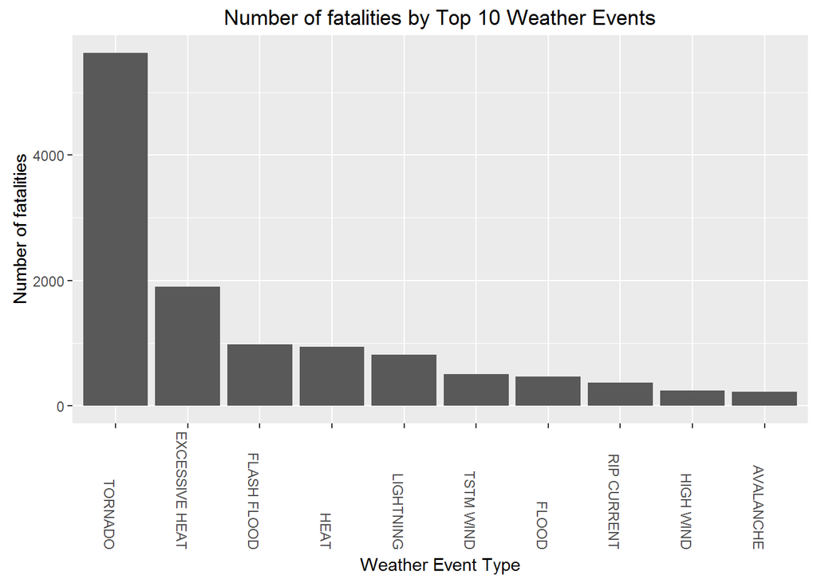

```r
library(ggplot2)
top10fatal$evt = factor(top10fatal$evt,levels=top10fatal$evt)
ggplot(top10fatal,aes(x=evt,y=fatalities)) + geom_bar(stat="identity") +
    theme(axis.text.x = element_text(angle = -90, hjust = 1)) +
    xlab("Weather Event Type") +
    ylab("Number of fatalities") +
    ggtitle("Number of fatalities by Top 10 Weather Events")
```

2.Below plot shows the top 10 weather events that caused maximum injuries:

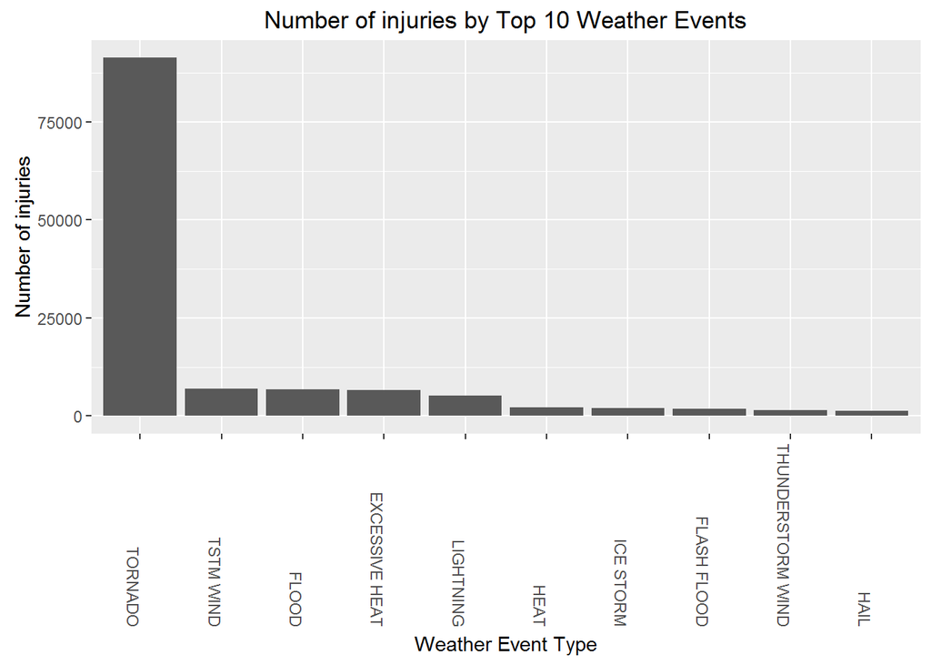

```r
ggplot(top10injuries,aes(x=evt,y=injuries)) + geom_bar(stat="identity") +
    theme(axis.text.x = element_text(angle = -90, hjust = 1)) +
    xlab("Weather Event Type") +
    ylab("Number of injuries") +
    ggtitle("Number of injuries by Top 10 Weather Events")
```

[figure not shown]

```r
ggplot(top10damages,aes(x=evt,y=damages)) + facet_grid(.~ Category)+ geom_bar(stat="identity") +
    theme(axis.text.x = element_text(angle = -90, hjust = 1)) +
    xlab("Weather Event Type") +
    ylab("Damages in US dollars") +
    ggtitle("Property & Crop damages by Top 10 Weather Events")
```